# R-Report VirágZábó

#Hypothesis VII. In general significantly more Hungarian people died of alcohol disorder than French people.

```r
wilcox.test(my_data_HUN$alcohol_disorders, my_data_FR$alcohol_disorders)
```

```
##
##  Wilcoxon rank sum exact test
##
## data:  my_data_HUN$alcohol_disorders and my_data_FR$alcohol_disorders
## W = 219, p-value = 0.0113
## alternative hypothesis: true location shift is not equal to 0
```

```r
mean(my_data_HUN$alcohol_disorders)
```

```
## [1] 0.5167196
```

```r
mean(my_data_FR$alcohol_disorders)
```

```
## [1] 0.6145799
```

```r
tablenew <- filter(my_data, country=="Hungary" | country== "France")
tablenew
```

[output not shown]

[output cut: 370 more lines]

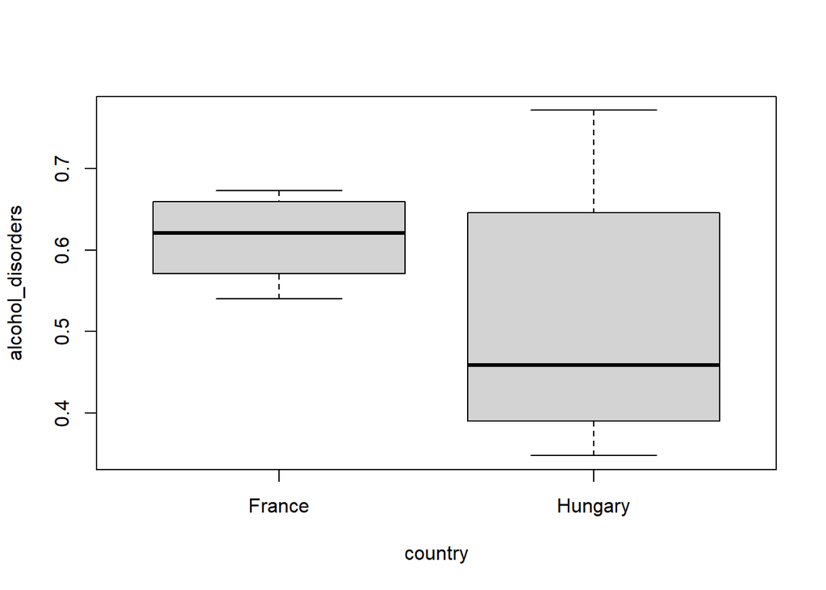

```r
boxplot(alcohol_disorders ~ country, data = tablenew)
```

The Wilcoxon rank test indicated that in general not significantly more Hungarian people (*M* = 0.52) died of alcohol disorder than French people (*M* = 0.61), W = 219, *p* = .01. The Wilcoxon rank test indicated that in general significantly more French people (*M* = 0.61) died of alcohol disorder than Hungarian (*M* = 0.52), W = 219, *p* = 0.01.

Note: Referring to the validity of the test, it is important to take into consideration the small sample size on which the test was performed.

#Hypothesis VIII. In general significantly more Hungarian people died of drug disorder than French people.

```r
wilcox.test(my_data_HUN$drug_disorders, my_data_FR$drug_disorders)
```

```
##
##  Wilcoxon rank sum exact test
##
## data:  my_data_HUN$drug_disorders and my_data_FR$drug_disorders
## W = 0, p-value = 1.027e-15
## alternative hypothesis: true location shift is not equal to 0
```

```r
mean(my_data_HUN$drug_disorders)
```

```
## [1] 0.06070356
```

```r
mean(my_data_FR$drug_disorders)
```

```
## [1] 0.2203011
```

```r
tablenew <- filter(my_data, country=="Hungary" | country== "France")
tablenew
```

[output not shown]

[output cut: 370 more lines]

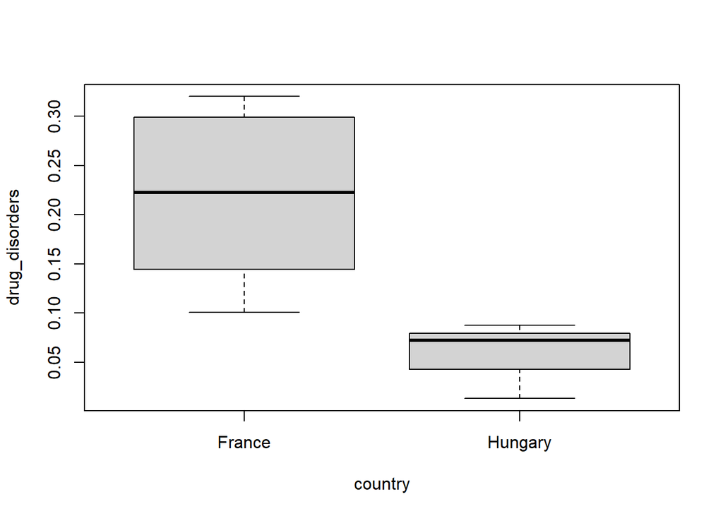

```r
boxplot(drug_disorders ~ country, data = tablenew)
```

The Wilcoxon rank test indicated that in general not significantly more Hungarian people (*M* = 0.06) died of drug disorder than French people (*M* = 0.22), W = 0, *p* < .001. The Wilcoxon rank test indicated that in general significantly more French people (*M* = 0.22) died of drug disorder than Hungarian people (*M* = 0.06), W = 0, *p* < .001.

Note: Referring to the validity of the test, it is important to take into consideration the small sample size on which the test was performed.